# Bank + Marketing Data

```r
library(tidyverse)
library(caret)
```

```r
library(leaps)
library(dplyr)
library(ggplot2)
library(ROSE)
dataset = read.csv('insurance2.csv')
```

```r
df = subset(dataset, select = -c(Group,Seq.nr,job,contact,day,month,duration,poutcome,pdays))
```

We need to encode the categorical data.

```r
df$marital = factor(df$marital,
                    levels = c('married','single','divorced'),
                    labels = c(1,2,3))

df$marital = as.numeric(as.character(df$marital))

df$education = factor(df$education,
                      level = c('tertiary','secondary','primary','unknown'),
                      labels = c(1,2,3,4))

df$education = as.numeric(as.character(df$education))

df$default = factor(df$default,
                    levels = c('yes','no'),
                    labels = c(1,0))

df$default = as.numeric(as.character(df$default))

df$housing = factor(df$housing,
                    levels = c('yes','no'),
                    labels = c(1,0))

df$housing = as.numeric(as.character(df$housing))

df$loan = factor(df$loan,
                    levels = c('yes','no'),
                    labels = c(1,0))

df$loan = as.numeric(as.character(df$loan))

df$y = factor(df$y,
                 levels = c('yes','no'),
                 labels = c(1,0))

#df$y = as.numeric(as.character(df$y))
```

We see that the target variable y is very imbalanced. The number of “yes” classification is far fewer than that of “No”. That is very unbalanced. Lets determine the fraction of “Yes” In the data set. We need to do some resampling of the training data.

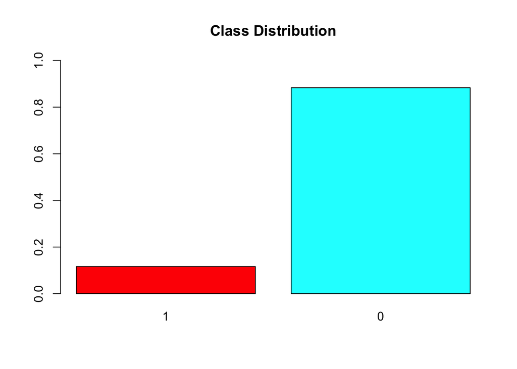

```r
df2 <- as.numeric(as.character(df$y))

barplot(prop.table(table(df$y)),
        col = rainbow(2),
        ylim = c(0, 1),
        main = "Class Distribution")
```

```r
require(dplyr)
df2 <- as.numeric(as.character(df$y))
table(df2)
```

```
## df2
##     0     1
## 35330  4670
```

There are number of sampling techniques we can use to balance the data such as over-sampling, under-sampling, both have their own disadvantages. OverSampling can lead to repeated obsevation. Undersampling is deprived of information from the original data, which leads to innacuracies. the ROSE package can generate data synthetically and is considered to provide better estimates of the data and will be used here.

```r
library(ROSE)
table(df$y)
```

```
##
##     1     0
##  4670 35330
```

```r
prop.table(table(df$y))
```

```
##
##       1       0
## 0.11675 0.88325
```

As we see, this data set contains only 11% of positive cases and 89% of negative cases. This is a severely imbalanced data set.

Let’s build a model on this data. I’ll be using decision tree algorithm for modeling purpose.

Data is split first.

```r
library(caTools)
set.seed(123)
split = sample.split(df$y, SplitRatio = 0.90)
training_set = subset(df, split == TRUE)
test_set = subset(df, split == FALSE)
```

Feature scaling

```r
training_set[-10] = scale(training_set[-10])
test_set[-10] = scale(test_set[-10])
```

Create a model

```r
library(rpart)
treeimb <- rpart(y ~ ., data = training_set)
pred.treeimb <- predict(treeimb, newdata = test_set)
```

Let’s check the accuracy of this prediction. To check accuracy, ROSE package has a function names *accuracy.meas*, it computes important metrics such as precision, recall & F measure

```r
accuracy.meas(test_set$y, pred.treeimb[,2])
```

```
##
## Call:
## accuracy.meas(response = test_set$y, predicted = pred.treeimb[,
##     2])
##
## Examples are labelled as positive when predicted is greater than 0.5
##
## precision: 0.883
## recall: 1.000
## F: 0.469
```

```r
roc.curve(test_set$y, pred.treeimb[,2], plotit = F)
```

```
## Area under the curve (AUC): 0.500
```

The data generated from oversampling have expected amount of repeated observations. Data generated from undersampling is deprived of important information from the original data. This leads to inaccuracies in the resulting performance. To encounter these issues, ROSE helps us to generate data synthetically as well. The data generated using ROSE is considered to provide better estimate of original data.

```r
data.rose <- ROSE(y~ ., data = training_set, seed = 1)$data
table(data.rose$y)
```

```
##
##     0     1
## 18070 17930
```

```r
head(data.rose)
```

|  | age | marital | education | default | balance | housing | loan | campaign | previous | y |
| --- | --- | --- | --- | --- | --- | --- | --- | --- | --- | --- |
| 1 | -1.1936184 | 2.7598475 | -0.3354329 | -0.03339575 | 0.07499338 | -1.5996549 | -0.04751177 | 0.819336894 | 0.1206278 | 0 |
| 2 | -2.3916505 | 0.1465733 | 2.2536801 | -0.27439178 | -0.12613465 | -1.0424029 | -0.42122220 | -1.416116276 | 0.2020322 | 0 |
| 3 | 2.6474501 | -1.1523523 | 0.4013392 | -0.68045553 | 0.42733007 | -1.3270957 | 0.06638628 | 0.388290170 | -0.3443467 | 0 |
| 4 | 2.4129727 | -0.3226441 | 1.6824596 | -0.40920777 | -0.05836061 | -0.7526272 | -0.50892409 | -0.500391350 | -0.4653294 | 0 |
| 5 | -0.8978447 | 1.0725020 | -0.5557987 | -0.37145676 | -0.19967994 | 1.3513390 | 2.76530010 | -0.314507031 | 1.5937518 | 0 |
| 6 | 0.6840711 | -0.1947196 | -0.1265541 | -0.06900858 | 0.01426316 | -1.3031328 | 2.77109574 | 0.004292161 | -1.2530880 | 0 |

```r
library(caTools)
set.seed(123)
split = sample.split(data.rose$y, SplitRatio = 0.90)
training_set = subset(data.rose, split == TRUE)
test_set = subset(data.rose, split == FALSE)
```

Check Correlation, Use Pearson Correlation. We may want to remove some variables if they are strongly correlated.

```r
library("Hmisc")
res3 <- rcorr(as.matrix(training_set[-11]))
res3
```

```
##             age marital education default balance housing  loan campaign
## age        1.00   -0.12      0.17   -0.02    0.10   -0.14 -0.03    -0.01
## marital   -0.12    1.00     -0.07    0.03   -0.03   -0.01 -0.01    -0.03
## education  0.17   -0.07      1.00    0.01   -0.03    0.04  0.01     0.02
## default   -0.02    0.03      0.01    1.00   -0.05    0.01  0.07     0.01
## balance    0.10   -0.03     -0.03   -0.05    1.00   -0.06 -0.07    -0.01
## housing   -0.14   -0.01      0.04    0.01   -0.06    1.00  0.08     0.01
## loan      -0.03   -0.01      0.01    0.07   -0.07    0.08  1.00     0.02
## campaign  -0.01   -0.03      0.02    0.01   -0.01    0.01  0.02     1.00
## previous   0.02    0.00     -0.03   -0.03    0.02    0.00 -0.02    -0.05
## y          0.03    0.07     -0.07   -0.04    0.06   -0.19 -0.10    -0.12
##           previous     y
## age           0.02  0.03
## marital       0.00  0.07
## education    -0.03 -0.07
## default      -0.03 -0.04
## balance       0.02  0.06
## housing       0.00 -0.19
## loan         -0.02 -0.10
## campaign     -0.05 -0.12
## previous      1.00  0.14
## y             0.14  1.00
##
## n= 32400
##
##
## P
##           age    marital education default balance housing loan   campaign
## age              0.0000  0.0000    0.0034  0.0000  0.0000  0.0000 0.0436
## marital   0.0000         0.0000    0.0000  0.0000  0.0768  0.0237 0.0000
## education 0.0000 0.0000            0.0084  0.0000  0.0000  0.0937 0.0055
## default   0.0034 0.0000  0.0084            0.0000  0.0493  0.0000 0.0159
## balance   0.0000 0.0000  0.0000    0.0000          0.0000  0.0000 0.0430
## housing   0.0000 0.0768  0.0000    0.0493  0.0000          0.0000 0.0234
## loan      0.0000 0.0237  0.0937    0.0000  0.0000  0.0000         0.0000
## campaign  0.0436 0.0000  0.0055    0.0159  0.0430  0.0234  0.0000
## previous  0.0032 0.4610  0.0000    0.0000  0.0005  0.8297  0.0033 0.0000
## y         0.0000 0.0000  0.0000    0.0000  0.0000  0.0000  0.0000 0.0000
##           previous y
## age       0.0032   0.0000
## marital   0.4610   0.0000
## education 0.0000   0.0000
## default   0.0000   0.0000
## balance   0.0005   0.0000
## housing   0.8297   0.0000
## loan      0.0033   0.0000
## campaign  0.0000   0.0000
## previous           0.0000
## y         0.0000
```

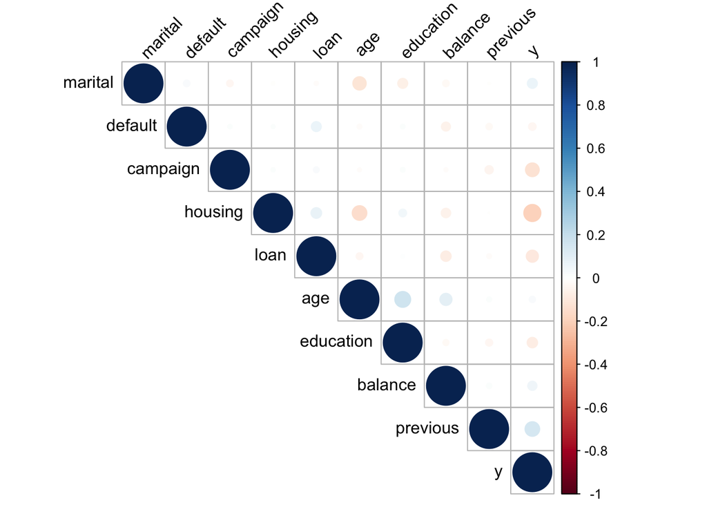

```r
library(corrplot)
corrplot(res3$r, type = "upper", order = "hclust",
         tl.col = "black", tl.srt = 45)
```

The variables we have are not strong correlated to one another

Fitting Logistic Regression to the Training set

```r
mod1 <- glm(formula = y ~ .,
                 family  = binomial,
                 data = training_set)
summary(mod1)
```

```
##
## Call:
## glm(formula = y ~ ., family = binomial, data = training_set)
##
## Deviance Residuals:
##     Min       1Q   Median       3Q      Max
## -3.6778  -1.0890  -0.4207   1.0845   2.8016
##
## Coefficients:
##             Estimate Std. Error z value Pr(>|z|)
## (Intercept) -0.15579    0.01203 -12.948  < 2e-16 ***
## age          0.01191    0.00972   1.226     0.22
## marital      0.11910    0.01066  11.167  < 2e-16 ***
## education   -0.10345    0.01056  -9.794  < 2e-16 ***
## default     -0.05597    0.01237  -4.524 6.08e-06 ***
## balance      0.07017    0.01101   6.376 1.82e-10 ***
## housing     -0.34749    0.01079 -32.199  < 2e-16 ***
## loan        -0.15932    0.01192 -13.365  < 2e-16 ***
## campaign    -0.29155    0.01457 -20.003  < 2e-16 ***
## previous     0.26207    0.01122  23.357  < 2e-16 ***
## ---
## Signif. codes:  0 '***' 0.001 '**' 0.01 '*' 0.05 '.' 0.1 ' ' 1
##
## (Dispersion parameter for binomial family taken to be 1)
##
##     Null deviance: 44915  on 32399  degrees of freedom
## Residual deviance: 41952  on 32390  degrees of freedom
## AIC: 41972
##
## Number of Fisher Scoring iterations: 4
```

We need to do variable selection.

```r
library(MASS)
mod_set <- stepAIC(mod1, direction = 'backward', trace = FALSE)
mod_set
```

```
##
## Call:  glm(formula = y ~ marital + education + default + balance + housing +
##     loan + campaign + previous, family = binomial, data = training_set)
##
## Coefficients:
## (Intercept)      marital    education      default      balance      housing
##    -0.15571      0.11767     -0.10127     -0.05607      0.07132     -0.34942
##        loan     campaign     previous
##    -0.15957     -0.29164      0.26243
##
## Degrees of Freedom: 32399 Total (i.e. Null);  32391 Residual
## Null Deviance:       44920
## Residual Deviance: 41950     AIC: 41970
```

```r
library(bootStepAIC)
mod_boot <- boot.stepAIC(mod1, training_set, B=50)
mod_boot
```

```
##
## Summary of Bootstrapping the 'stepAIC()' procedure for
##
## Call:
## glm(formula = y ~ ., family = binomial, data = training_set)
##
## Bootstrap samples: 50
## Direction: backward
## Penalty: 2 * df
##
## Covariates selected
##           (%)
## balance   100
## campaign  100
## default   100
## education 100
## housing   100
## loan      100
## marital   100
## previous  100
## age        46
##
## Coefficients Sign
##           + (%) - (%)
## age         100     0
## balance     100     0
## marital     100     0
## previous    100     0
## campaign      0   100
## default       0   100
## education     0   100
## housing       0   100
## loan          0   100
##
## Stat Significance
##              (%)
## balance   100.00
## campaign  100.00
## default   100.00
## education 100.00
```

[output cut: 22 more lines]

```
## Stepwise Model Path
## Analysis of Deviance Table
##
## Initial Model:
## y ~ age + marital + education + default + balance + housing +
##     loan + campaign + previous
##
## Final Model:
## y ~ marital + education + default + balance + housing + loan +
##     campaign + previous
##
##
##    Step Df Deviance Resid. Df Resid. Dev      AIC
## 1                       32390   41951.66 41971.66
## 2 - age  1 1.502409     32391   41953.16 41971.16
```

Using stepAIC bootstrap, we arrive at the final model shown.

```r
mod2 <- glm(formula = y ~ marital + education + default + balance + housing + loan +
    campaign + previous,
                 family  = binomial(link="logit"),
                 data = training_set)
summary(mod2)
```

```
##
## Call:
## glm(formula = y ~ marital + education + default + balance + housing +
##     loan + campaign + previous, family = binomial(link = "logit"),
##     data = training_set)
##
## Deviance Residuals:
##     Min       1Q   Median       3Q      Max
## -3.6814  -1.0897  -0.4205   1.0846   2.8034
##
## Coefficients:
##             Estimate Std. Error z value Pr(>|z|)
## (Intercept) -0.15571    0.01203 -12.942  < 2e-16 ***
## marital      0.11767    0.01060  11.103  < 2e-16 ***
## education   -0.10127    0.01041  -9.727  < 2e-16 ***
## default     -0.05607    0.01237  -4.533 5.82e-06 ***
## balance      0.07132    0.01097   6.502 7.94e-11 ***
## housing     -0.34942    0.01068 -32.720  < 2e-16 ***
## loan        -0.15957    0.01192 -13.387  < 2e-16 ***
## campaign    -0.29164    0.01457 -20.014  < 2e-16 ***
## previous     0.26243    0.01122  23.393  < 2e-16 ***
## ---
## Signif. codes:  0 '***' 0.001 '**' 0.01 '*' 0.05 '.' 0.1 ' ' 1
##
## (Dispersion parameter for binomial family taken to be 1)
##
##     Null deviance: 44915  on 32399  degrees of freedom
## Residual deviance: 41953  on 32391  degrees of freedom
## AIC: 41971
##
## Number of Fisher Scoring iterations: 4
```

Return exponentiated coefficients to get the odds ratio.

```r
OR <- data.frame(exp(mod2$coefficients))
OR_Perc <- (OR-1)*100
OR_Perc
```

|  | exp.mod2.coefficients. |
| --- | --- |
| (Intercept) | -14.419043 |
| marital | 12.486727 |
| education | -9.630691 |
| default | -5.452764 |
| balance | 7.392543 |
| housing | -29.490148 |
| loan | -14.748808 |
| campaign | -25.296603 |
| previous | 30.008788 |

Use model to make some predictions

```r
predict(mod2,training_set, type = "response")
```

[output not shown]

[output cut: 9203 more lines]

[output not shown]

```r
glm_probs = data.frame(probs = predict(mod2,
                                       newdata = training_set,
                                       type="response"))
```

```r
glm_pred = glm_probs %>%
  mutate(pred = ifelse(probs>.5, "0", "1"))


glm_pred = cbind(training_set, glm_pred)
```

```r
probabilities <- mod2 %>% predict(training_set, type = "response")
predicted.classes <- ifelse(probabilities> 0.5, 0, 1)
# Model Accuracy
mean(predicted.classes == training_set$y)
```

```
## [1] 0.3640741
```

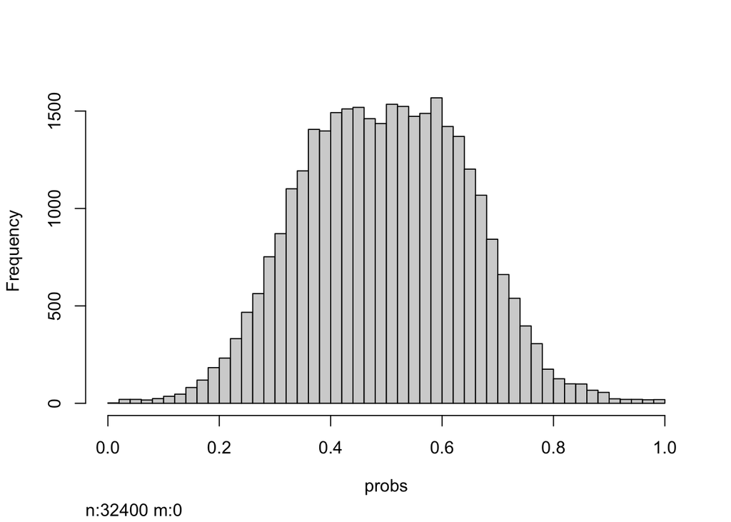

```r
hist(glm_probs)
```

The default cutoff prediction probability score is 0.5 or the ratio of 1’s and 0’s in the training data. But sometimes, tuning the probability cutoff can improve the accuracy in both the development and validation samples. The `InformationValue::optimalCutoff` function provides ways to find the optimal cutoff to improve the prediction of 1’s, 0’s, both 1’s and 0’s and o reduce the misclassification error. Lets compute the optimal score that minimizes the misclassification error for the above model.

```r
library(InformationValue)
optCutOff <- optimalCutoff(glm_pred$y, glm_probs)[1]
optCutOff
```

```
## [1] 0.5192709
```

```r
library(caret)
CM <- confusionMatrix(glm_pred$y, predict(mod2,training_set, type = "response"))
CM
```

|  | 0 | 1 |
| --- | --- | --- |
| 0 | 10375 | 5908 |
| 1 | 5888 | 10229 |

```r
accuracy.meas(glm_pred$y, glm_pred$pred)
```

```
##
## Call:
## accuracy.meas(response = glm_pred$y, predicted = glm_pred$pred)
##
## Examples are labelled as positive when predicted is greater than 0.5
##
## precision: 0.363
## recall: 0.366
## F: 0.182
```